# Donal O Farrell

It would be interesting to know what the properties of the high chloride outliers that can be seen are and if there are any clues as to what causes such high chloride content.

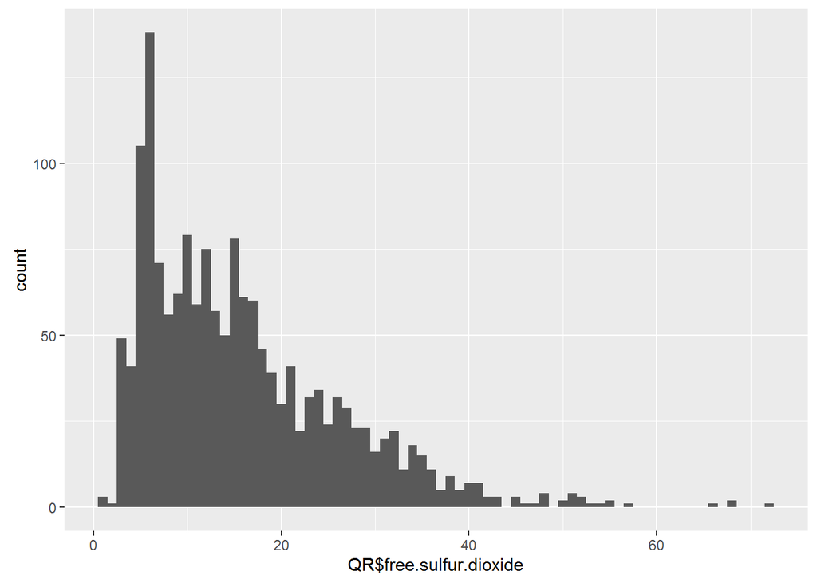

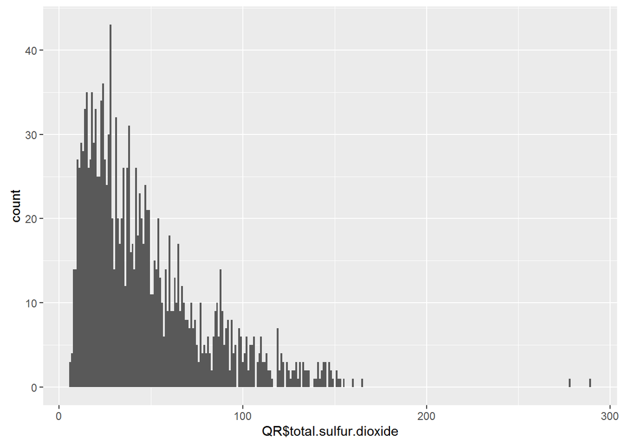

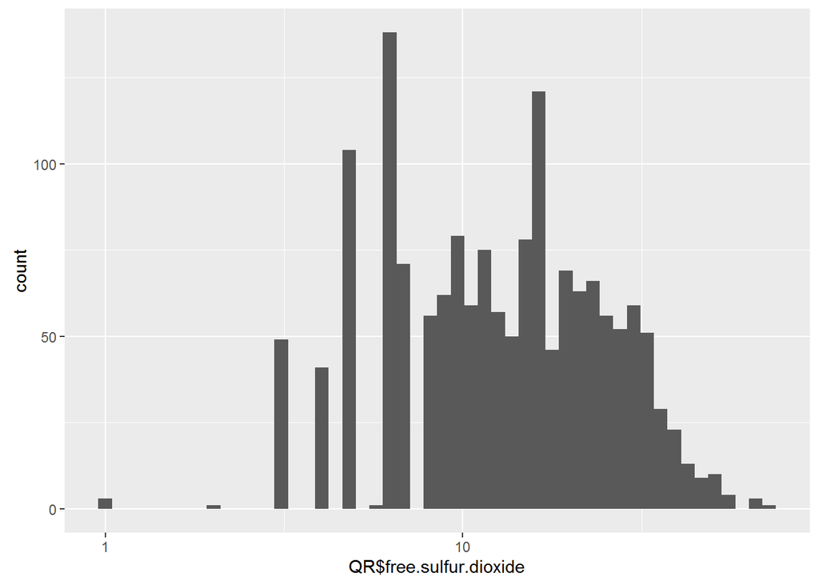

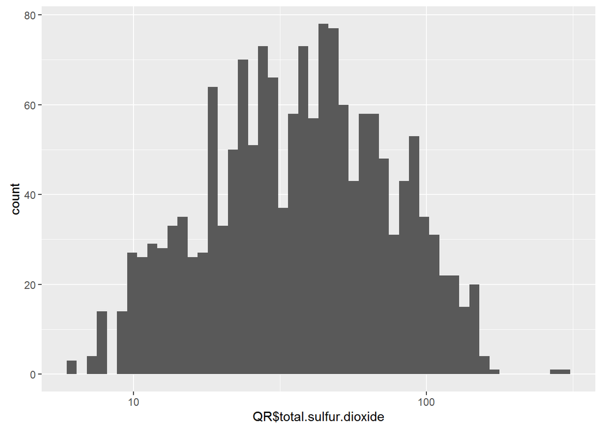

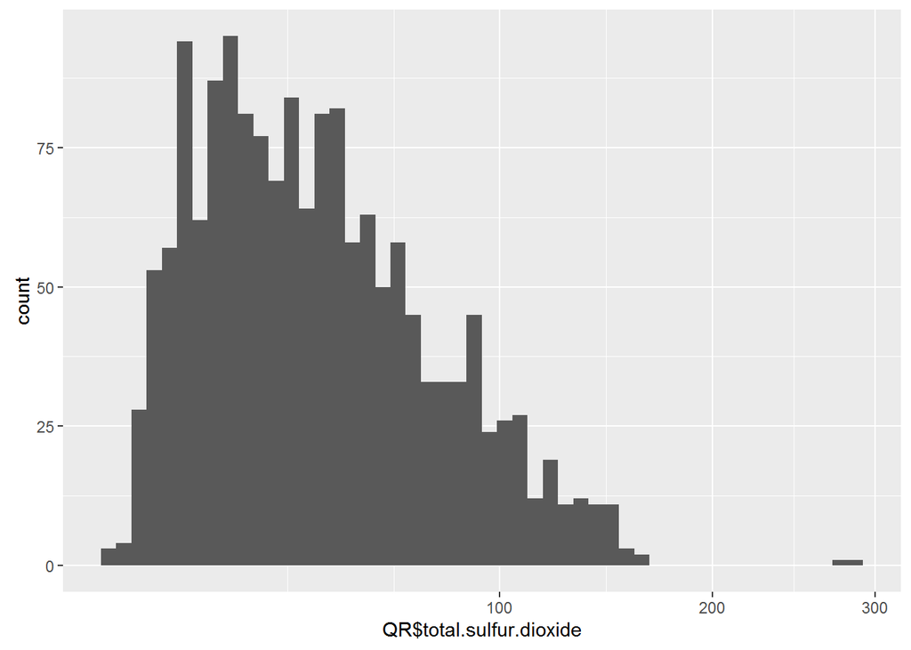

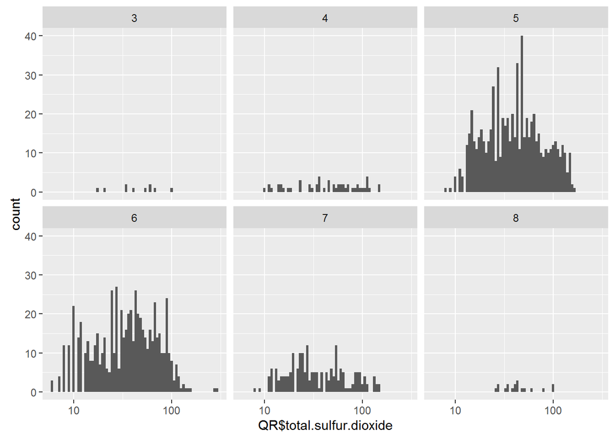

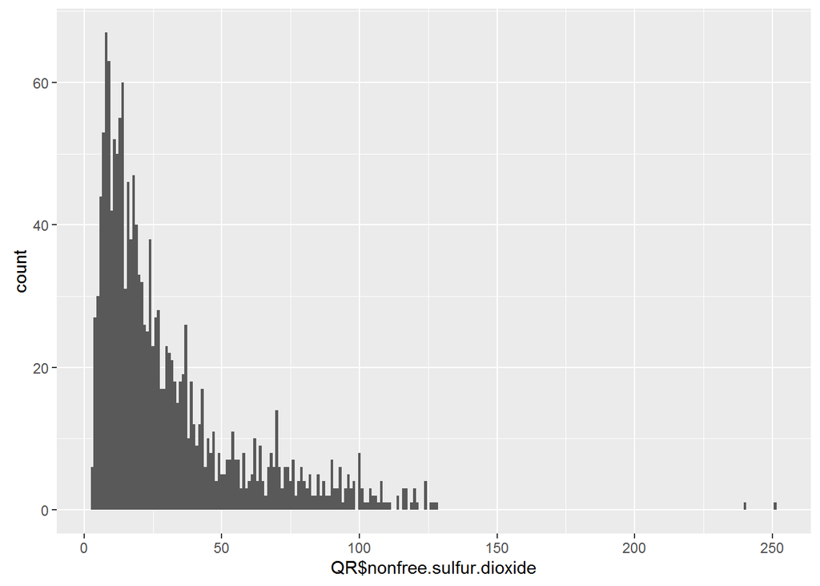

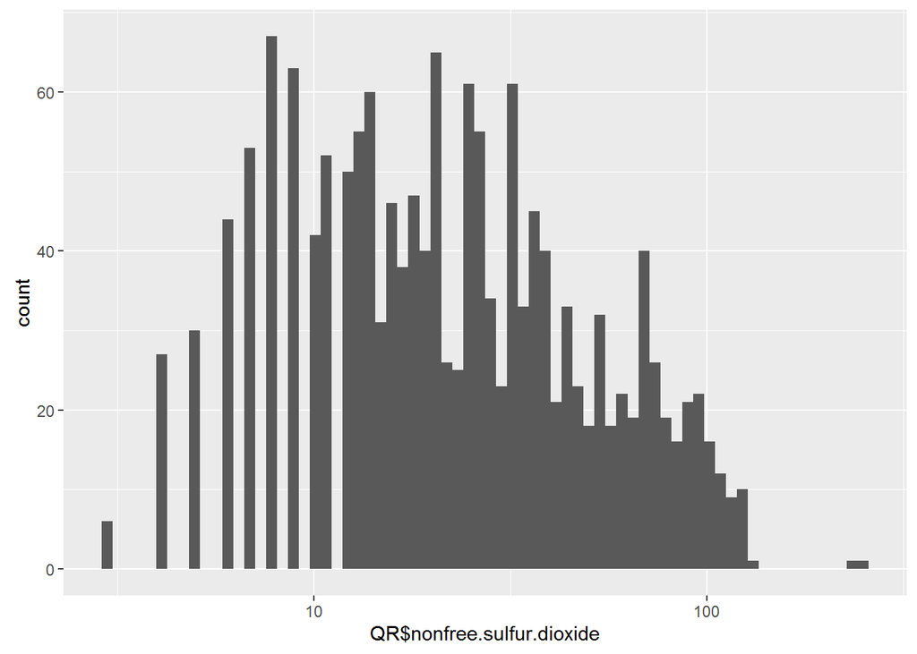

There are two measures of sulfur dioxide in the data set, free and total. Both appear to have extremely long tailed distributions but applying a log10 scale to the plots created a more normal distribution. Facet wrap of the total sulfur dioxide shows no major shifts in the distribution though a slight hint of bimodality can be seen for quality = 6.

Assuming the free sulfur dioxide is a subset of the total, a new variable for the non-free sulfur dioxide was created to investigate if there us anything of interest in the residual of the two variables. The non-free distribution is a similar distribution to the other measures of sulfur dioxide, with a log scale giving a more normal distribution.

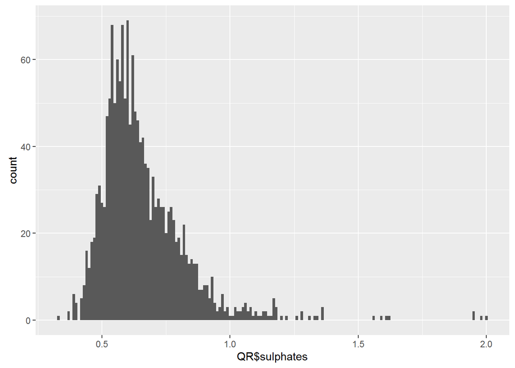

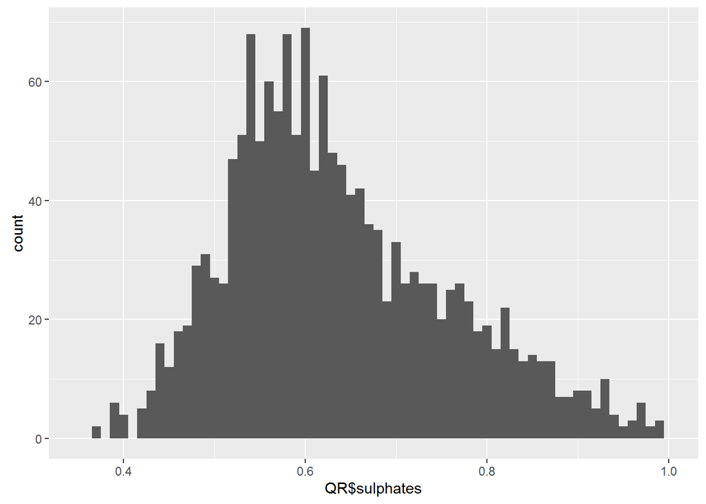

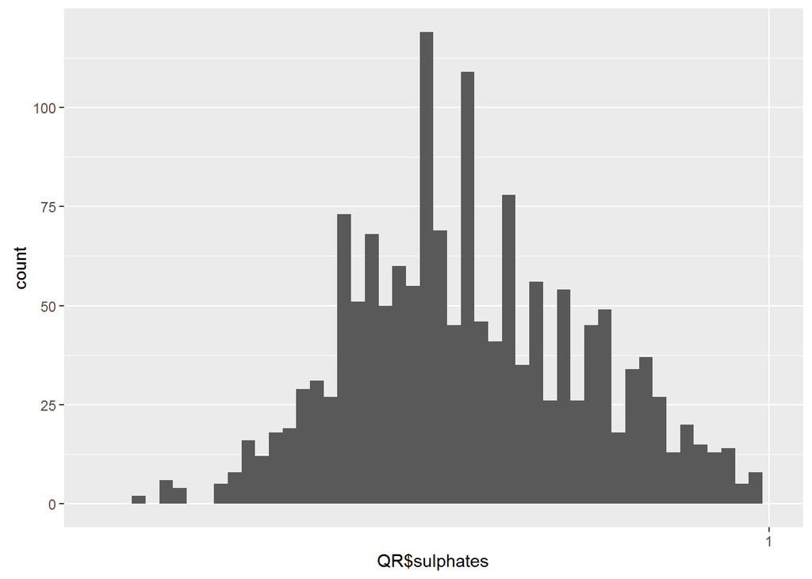

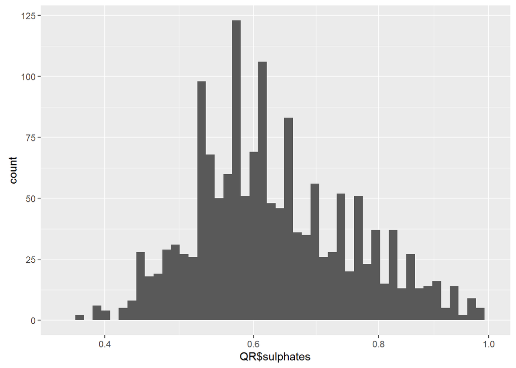

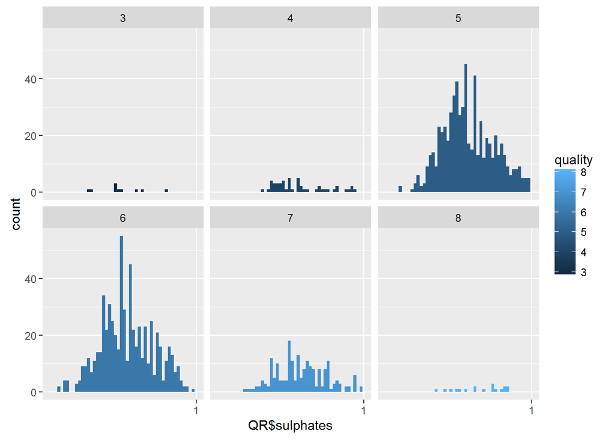

The sulfate is another long tallied distribution where applying a log10 scale leads a far more normal looking plot. Applying a square root also helps but is less effective. Faceting over quality shows no major differences between the distributions for difference for different quality levels.

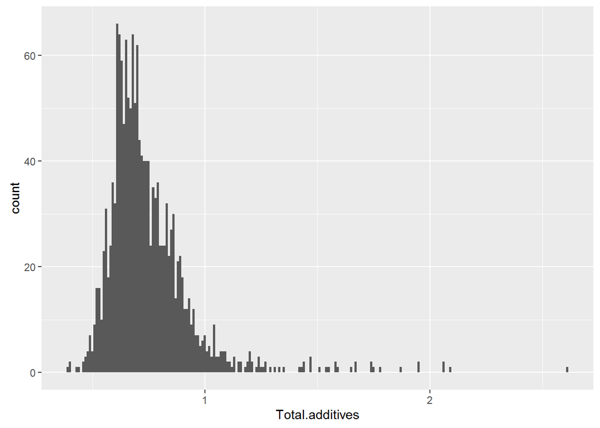

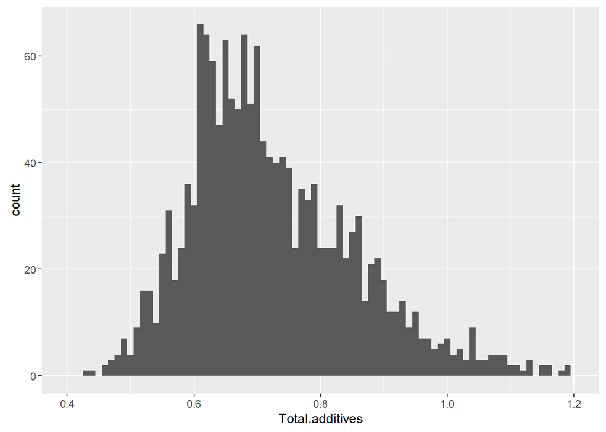

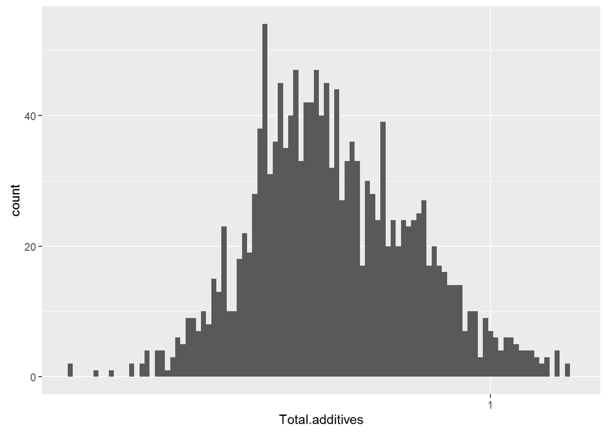

Finally, due to the similarity in distributions and the hint of connections between the variables, a new variable was created (‘Total.additives’) that is the simple sum of sulphates and chlorides.

# Univariate Analysis

### What is/are the main feature(s) of interest in your dataset?

The main feature of the data-set is the assigned quality of the wines, a key question of this investigation will be to see how the other properties of the wines influence this quality factor.

### What other features in the dataset do you think will help support your investigation into your feature(s) of interest?

Other important features are the residual sugar, alcohol and pH variable as these are likely to have the biggest impact on the properties of the wine.

### Did you create any new variables from existing variables in the dataset?

New variables non-free.sulfur.dioxide and Total.additives were created.

### Of the features you investigated, were there any unusual distributions? Did you perform any operations on the data to tidy, adjust, or change the form of the data? If so, why did you do this?

Several variables (suphides and sulfur dioxide) appear to be log10 distributed and residual sugars appears square root distributed.

No changes were made to adjust the data at this stage. It may be useful to change the quality data to a factor, but so far this has not been done for ease of plotting.

# Bivariate Plots Section

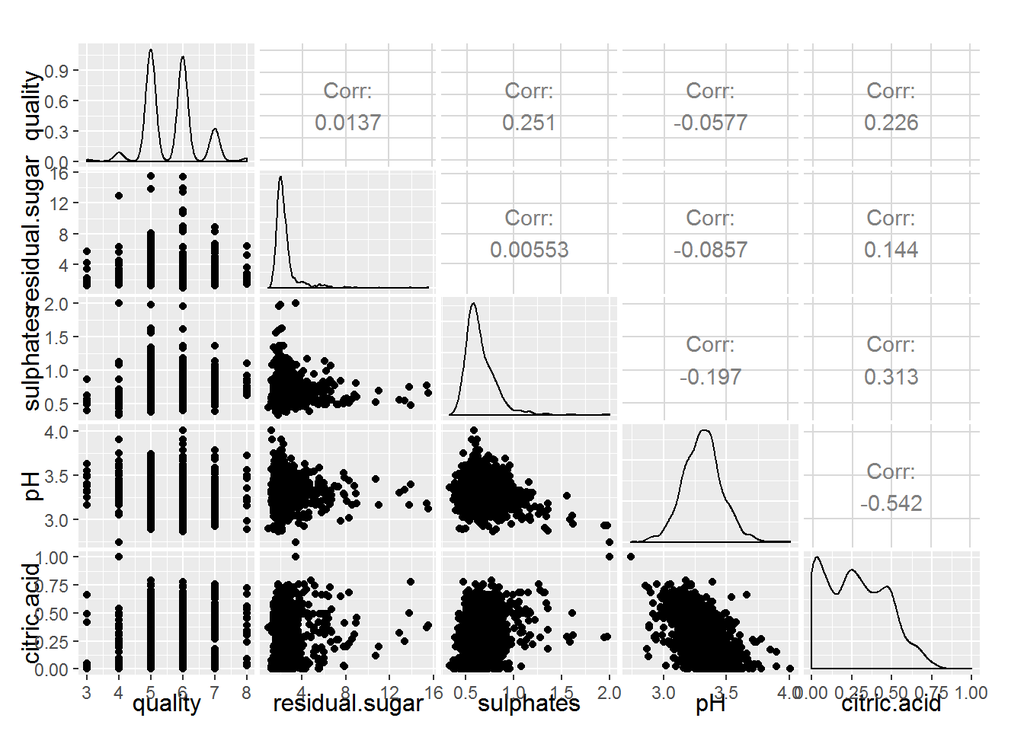

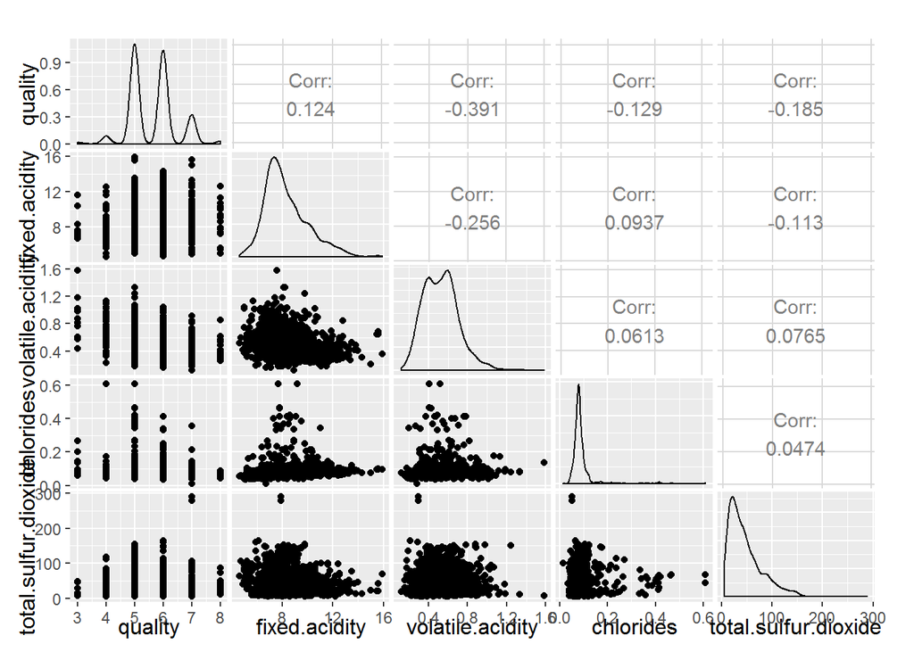

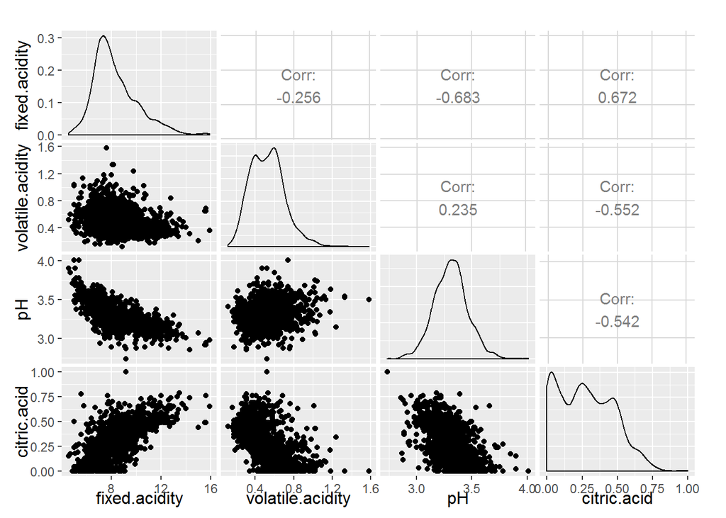

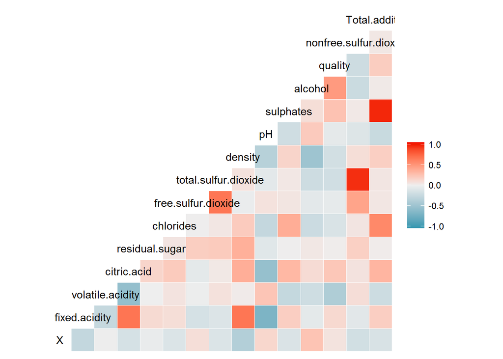

From the plotted variable some positive correlation between sulphates and citric acid can be seen.

A negative correlation between pH and citric acid is seen, it is likely this is one of the several acidity indicators that contributes to pH. The negative correlation makes sense as pH decreases with increasing acidity.

The strongest correlation to quality form the second ggally matrix is the negative correlation to volatile acidity (-0.391) Top 4 influencers of wine quality bucket are below. This correlation test only gives a measure of linear dependence so focusing on these variable may exclude any non linear relationships but this is beyond the scope of this first pass at the data set. sulpates = 0.251 citric acid = 0.226 volatile acidity = - 0.391 total sulphur dioxide = -0.185

Looking at the different measures of acidity there are clear relationships between some of the different measures of acidity. The strongest correlation is a negative correlation between pH and fixed acidity

There is a correlation between citric acid content and fixed acidity that suggests the possibility that these are not independent measures of acidity and the fixed acidity of a wine incorporates the impact of the citric acid content.

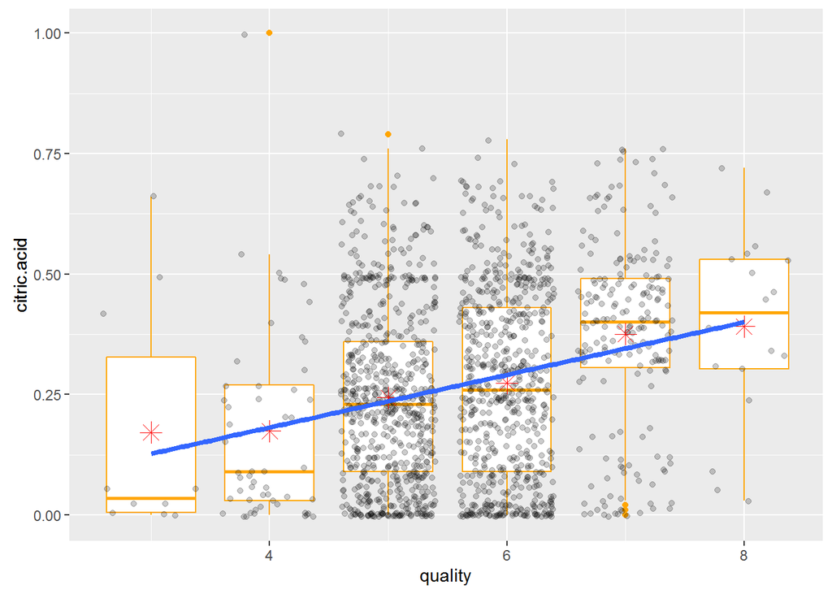

```
## [1] 0.2263725
```

From the box plot of citric acid by quality we can see the correlation between the citric acid content and quality. There is a slight increase in mean citric acid content between quality buckets 5 ad 6 but the big differences can be seen comparing the low quality buckets, with low citric acid, and the high quality buckets that show the reverse.

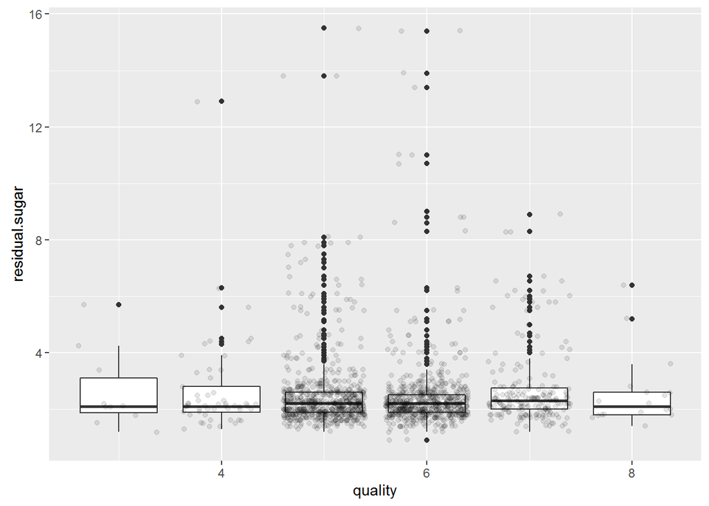

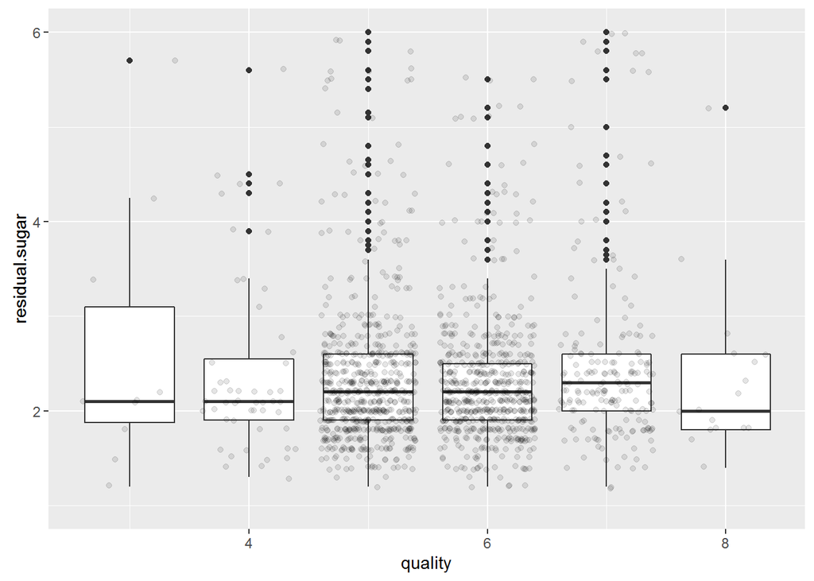

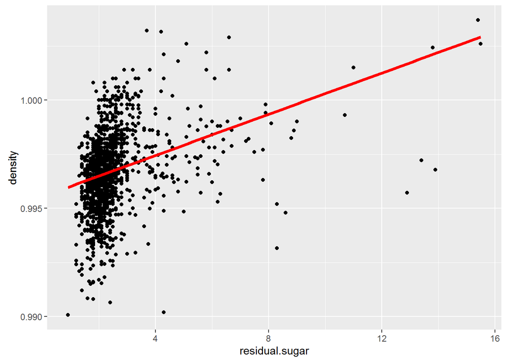

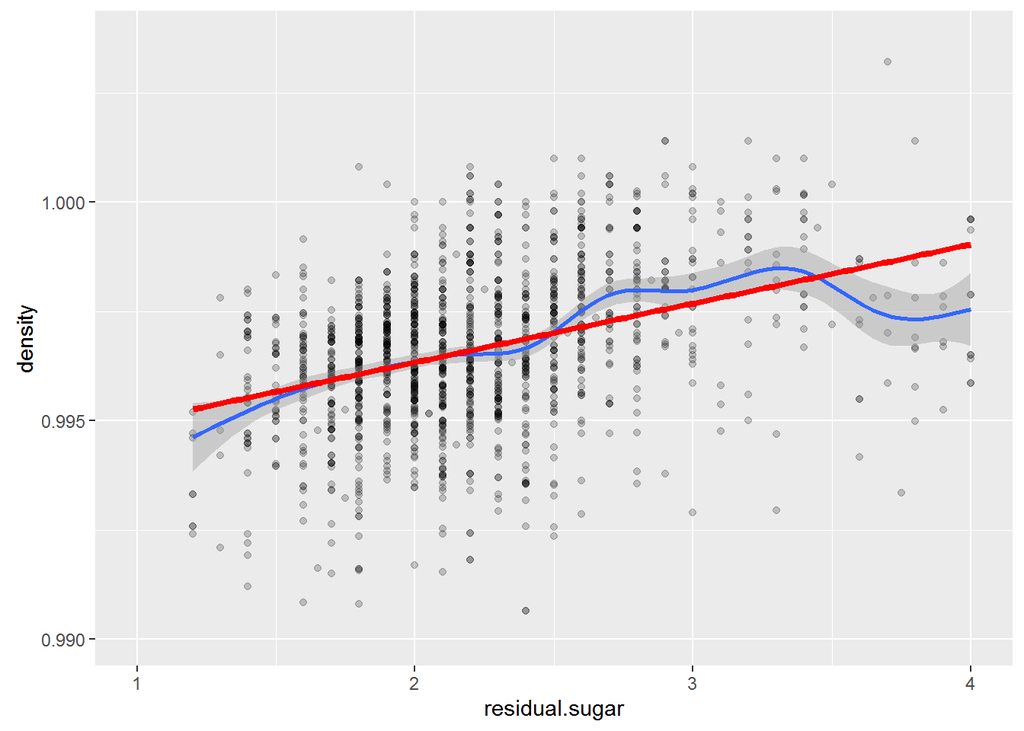

```
## [1] 0.3552834
```

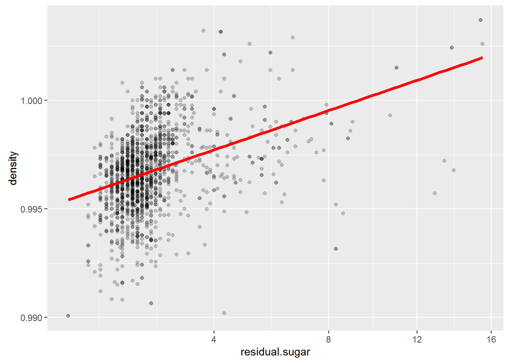

```
## $title
## [1] "density vs sqrt residual sugar"
##
## attr(,"class")
## [1] "labels"
```

Looking at residual sugars across the levels of quality there appears to be no correlation between residual sugar and quality.

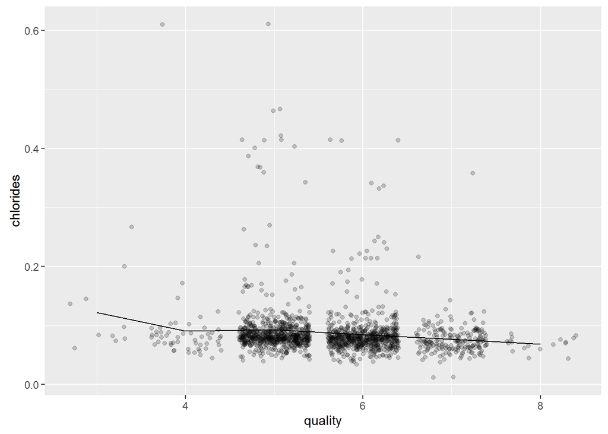

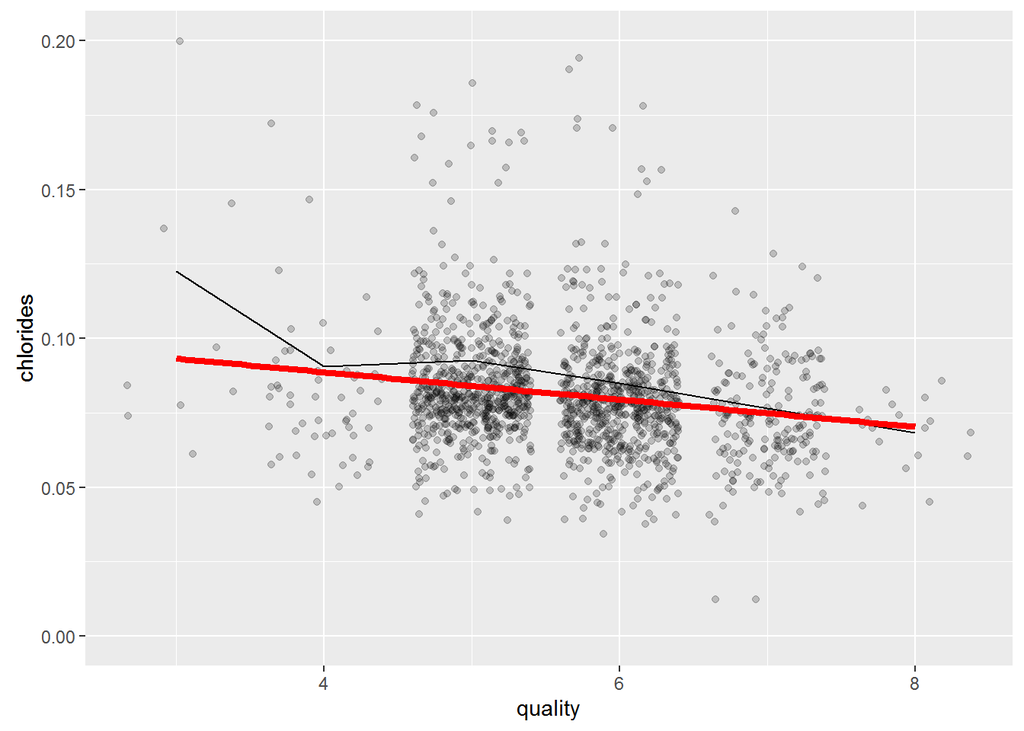

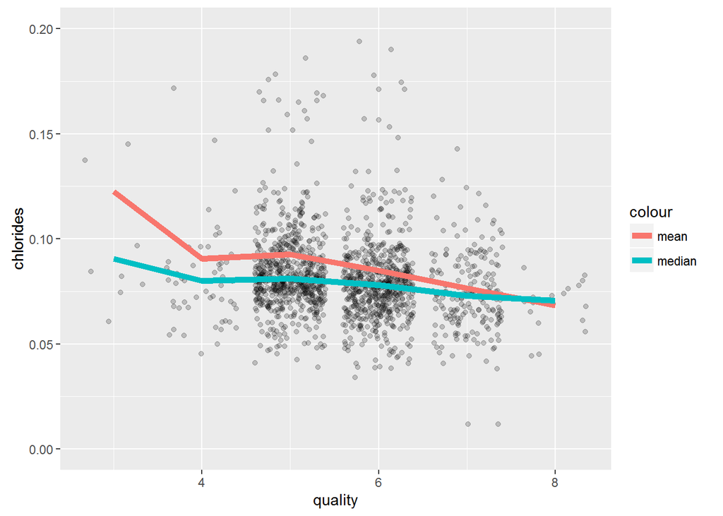

Chloride content looks static along the quality buckets.

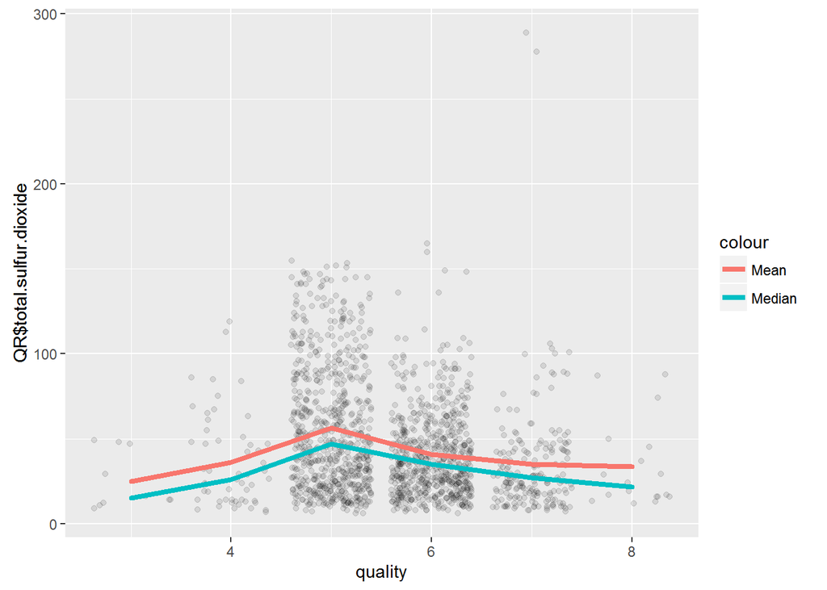

```
##
##  Pearson's product-moment correlation
##
## data:  QR$quality and QR$total.sulfur.dioxide
## t = -7.5271, df = 1597, p-value = 8.622e-14
## alternative hypothesis: true correlation is not equal to 0
## 95 percent confidence interval:
##  -0.2320162 -0.1373252
## sample estimates:
##        cor
## -0.1851003
```

From the trends in mean and median total sulfur dioxide over the different quality bins we can see there is not a clear linear negative correlation that the R value would suggest.

The clearest differences can be seen in the populations of bins 5, 6 and 7. The upper distribution of sulfur dioxide is eroded away giving a smaller range of sulfur dioxide values as the quality increases (ignoring outliers). This trend cannot be seen for the very low or very high quality buckets due to the lower overall populations. Its possible that if the data set was expanded to include a far higher number of observations for the low/high end of the quality scale the ranges would follow the same pattern as 5/6/7.

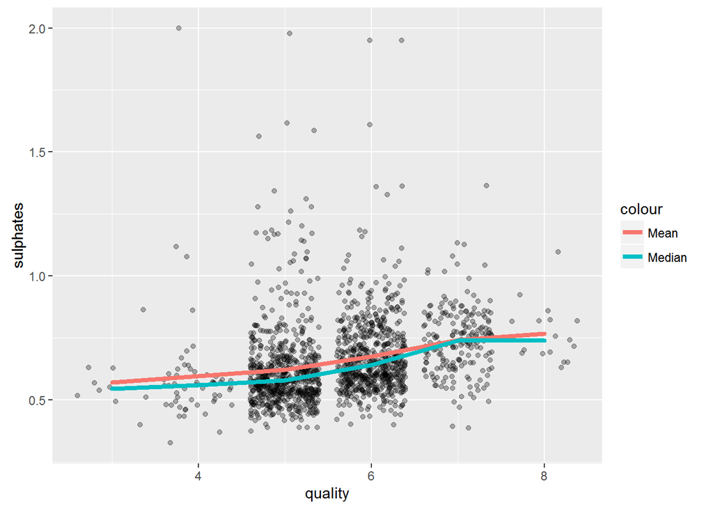

```
##
##  Pearson's product-moment correlation
##
## data:  QR$quality and QR$sulphates
## t = 10.38, df = 1597, p-value < 2.2e-16
## alternative hypothesis: true correlation is not equal to 0
## 95 percent confidence interval:
##  0.2049011 0.2967610
## sample estimates:
##       cor
## 0.2513971
```

The correlation between wine quality and sulphates appears more clear cut with a liner relationship between sulphates and quality evident in the bivariate plot above. The trends in mean/median hold most clearly for the highly populated quality buckets and the pattern falters for the highest/lowest quality wines. Again, a data set with a higher number of low/high quality wines might hold the linear relationship more closely. The value for Pearson’s R (0.25) is in line with the observed positive linear dependence.

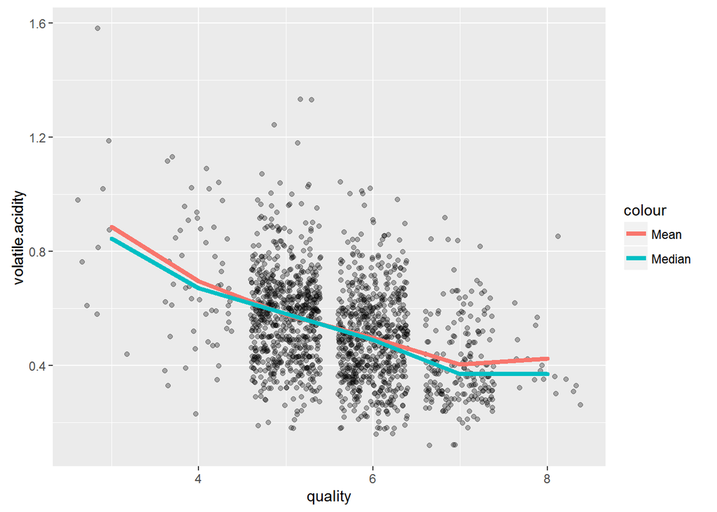

```
##
##  Pearson's product-moment correlation
##
## data:  QR$quality and QR$volatile.acidity
## t = -16.954, df = 1597, p-value < 2.2e-16
## alternative hypothesis: true correlation is not equal to 0
## 95 percent confidence interval:
##  -0.4313210 -0.3482032
## sample estimates:
##        cor
## -0.3905578
```

```
##
##  Welch Two Sample t-test
##
## data:  x and y
## t = 0, df = 3196, p-value = 1
## alternative hypothesis: true difference in means is not equal to 0
## 95 percent confidence interval:
##  -0.01241656  0.01241656
## sample estimates:
## mean of x mean of y
## 0.5278205 0.5278205
```

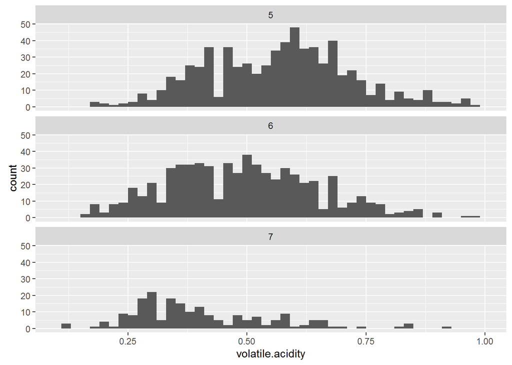

# Bivariate Analysis

### Talk about some of the relationships you observed in this part of the investigation. How did the feature(s) of interest vary with other features in the dataset?

There are clear relationships between some variables in the data set. Most striking is the negative relationship between wine quality and volatile acidity. With the exception of the highest quality wines there is a clear downward trend with increasing volatile acidity. This makes sense based the make-up of volatile acidity as composing mainly of acetic acid and other acids considered as spoilants that would negatively impact the flavor.

Less important variables impacting quality include citric acid, sulphates and total sulfur dioxide. The relationships between these variables are less straightforward and break down for the lowest and highest quality buckets.

Wine information from: http://waterhouse.ucdavis.edu/whats-in-wine/volatile-acidity

### Did you observe any interesting relationships between the other features (not the main feature(s) of interest)?

Other than looking at quality, we can see relationships between citric acid and pH that would be expected (pH being a measure of acidity). A linear relationship between residual sugars and density was also observed as would be expected given the large ,molecular weight of sugars.

### What was the strongest relationship you found?

As mentioned above the strongest relationship was the negative impact of volatile acidity on the wine quality.

# Multivariate Plots Section

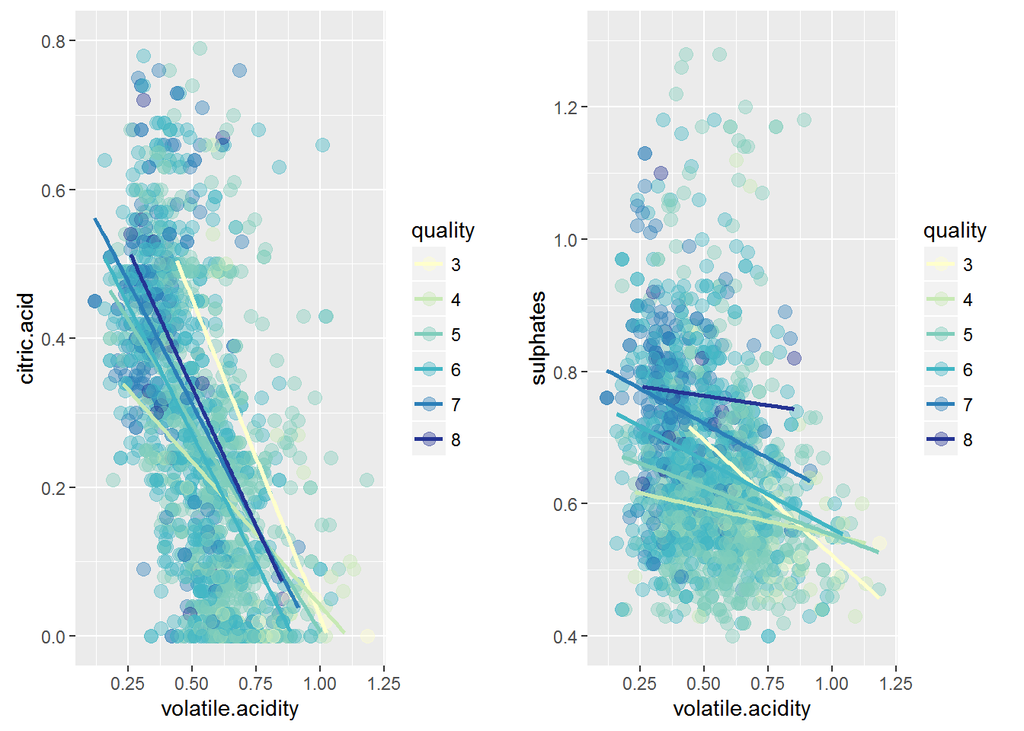

```
##
##  Pearson's product-moment correlation
##
## data:  QR$volatile.acidity and QR$citric.acid
## t = -26.489, df = 1597, p-value < 2.2e-16
## alternative hypothesis: true correlation is not equal to 0
## 95 percent confidence interval:
##  -0.5856550 -0.5174902
## sample estimates:
##        cor
## -0.5524957
```

```
##
##  Pearson's product-moment correlation
##
## data:  QR$volatile.acidity and QR$sulphates
## t = -10.804, df = 1597, p-value < 2.2e-16
## alternative hypothesis: true correlation is not equal to 0
## 95 percent confidence interval:
##  -0.3060917 -0.2147125
## sample estimates:
##        cor
## -0.2609867
```

Previous analysis above indicates the strongest correlations to wine quality are volatile acidity, citric acid and sulphates. To try understand how these variables determine quality as well as how the variables themselves interact the most influential variable on quality , volatile acidity, was plotted against the two next influential variables, citric acid and sulphates. Given the complex nature of wine quality it is possible that there exists ‘sweet spots’ for the variables that influence the wine quality. In the plots above it can be seen that there is a clustering of high quality for wines with high citric acid and low volatile acidity. More interestingly the is a clustering of high quality wines for higher sulphate content but this breaks down for higher sulphate wines with a higher volatile acidity.

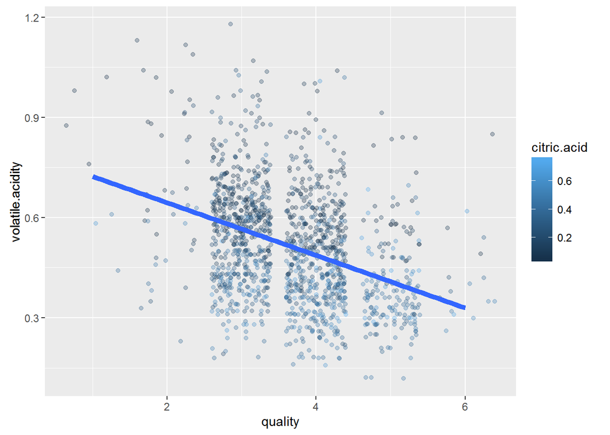

```
##
## Call:
## lm(formula = quality ~ I(-volatile.acidity) + I(-citric.acid),
##     data = QR.sub)
##
## Residuals:
##      Min       1Q   Median       3Q      Max
## -2.80626 -0.54603 -0.01478  0.45861  2.93262
##
## Coefficients:
##                      Estimate Std. Error t value Pr(>|t|)
## (Intercept)           4.42824    0.09815  45.117   <2e-16 ***
## I(-volatile.acidity)  1.61332    0.13779  11.708   <2e-16 ***
## I(-citric.acid)      -0.20924    0.12898  -1.622    0.105
## ---
## Signif. codes:  0 '***' 0.001 '**' 0.01 '*' 0.05 '.' 0.1 ' ' 1
##
## Residual standard error: 0.7449 on 1404 degrees of freedom
## Multiple R-squared:  0.1383, Adjusted R-squared:  0.137
## F-statistic: 112.6 on 2 and 1404 DF,  p-value: < 2.2e-16
```

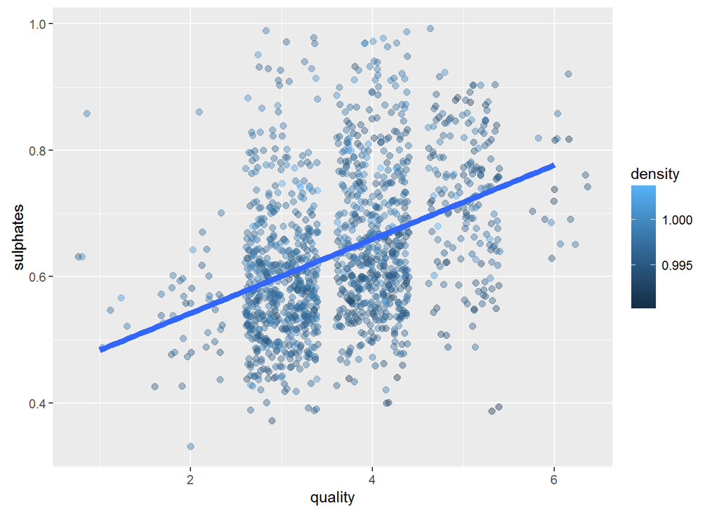

```
##
## Call:
## lm(formula = quality ~ I(-volatile.acidity) + I(-citric.acid) +
##     sulphates, data = QR.sub)
##
## Residuals:
##     Min      1Q  Median      3Q     Max
## -3.1900 -0.5048 -0.0554  0.4749  2.4065
##
## Coefficients:
##                      Estimate Std. Error t value Pr(>|t|)
## (Intercept)          3.042170   0.150393  20.228   <2e-16 ***
## I(-volatile.acidity) 1.264746   0.134781   9.384   <2e-16 ***
## I(-citric.acid)      0.003739   0.124405   0.030    0.976
## sulphates            1.983579   0.168391  11.780   <2e-16 ***
## ---
## Signif. codes:  0 '***' 0.001 '**' 0.01 '*' 0.05 '.' 0.1 ' ' 1
##
## Residual standard error: 0.7108 on 1403 degrees of freedom
## Multiple R-squared:  0.2158, Adjusted R-squared:  0.2141
## F-statistic: 128.7 on 3 and 1403 DF,  p-value: < 2.2e-16
```

```
## Analysis of Variance Table
##
## Response: quality
##                        Df Sum Sq Mean Sq  F value  Pr(>F)
## I(-volatile.acidity)    1 123.52 123.516 244.4727 < 2e-16 ***
## I(-citric.acid)         1   1.46   1.460   2.8899 0.08936 .
## sulphates               1  70.11  70.106 138.7598 < 2e-16 ***
## Residuals            1403 708.85   0.505
## ---
## Signif. codes:  0 '***' 0.001 '**' 0.01 '*' 0.05 '.' 0.1 ' ' 1
```

```
##
## Calls:
## lm1: lm(formula = quality ~ I(-volatile.acidity), data = QR.sub)
## lm2: lm(formula = quality ~ I(-volatile.acidity) + I(-citric.acid),
##     data = QR.sub)
## lm3: lm(formula = quality ~ I(-volatile.acidity) + I(-citric.acid) +
##     sulphates, data = QR.sub)
## lm4: lm(formula = quality ~ I(-volatile.acidity) + I(-citric.acid) +
##     sulphates + I(-density), data = QR.sub)
##
## =====================================================================
##                            lm1        lm2        lm3        lm4
## ---------------------------------------------------------------------
##   (Intercept)            4.550***   4.428***   3.042***  116.944***
##                         (0.063)    (0.098)    (0.150)    (10.928)
##   I(-volatile.acidity)   1.734***   1.613***   1.265***    0.803***
##                         (0.116)    (0.138)    (0.135)     (0.137)
##   I(-citric.acid)                  -0.209      0.004      -0.616***
##                                    (0.129)    (0.124)     (0.134)
##   sulphates                                    1.984***    2.181***
##                                               (0.168)     (0.163)
##   I(-density)                                            114.813***
##                                                          (11.015)
## ---------------------------------------------------------------------
##   R-squared                 0.14       0.14       0.22        0.27
##   adj. R-squared            0.14       0.14       0.21        0.27
##   sigma                     0.75       0.74       0.71        0.69
##   F                       222.37     112.63     128.71      131.10
##   p                         0.00       0.00       0.00        0.00
##   Log-likelihood        -1581.81   -1580.49   -1514.14    -1461.63
##   Deviance                780.41     778.95     708.85      657.86
##   AIC                    3169.62    3168.98    3038.29     2935.27
##   BIC                    3185.37    3189.98    3064.53     2966.76
##   N                      1407       1407       1407        1407
## =====================================================================
```

To further enhance the linear model suphates was plotted against quality to verify the existence of a positive relationship identified earlier. The overlay of density to the plot does not give as clear an impact as the addition of citric acid though adding this to the linear model margionally improves the R squared value.

# Multivariate Analysis

### Talk about some of the relationships you observed in this part of the investigation. Were there features that strengthened each other in terms of looking at your feature(s) of interest?

For citric acid and volatile acidity its clear the majority of highest quality wines are of both high citric acid and low volatile acidity. The high quality wines that are not of low volatile acidity are of low citric acid though this may just be a consequence of the clear inverse linear relationship between citric acid and volatile acidity. A correlation test confirms this relation with a R value of -0.55.

Looking a sulphates versus volatile acidity the high quality wines the highest quality wines are most prominent in the region of low volatile acidity and high sulphates content. The separation between high and low quality wines can be seen clearly with the majority of low and mid quality wines clustering in the area of higher volatile acidity and lower sulphate content. In this case there is again an inverse linear relationship visible between the sulphate and volatile acidity content and a Pearson’s R value of -0.26 confirms this less clear correlation.

### Were there any interesting or surprising interactions between features?

As detailed above there was an inverse relationship between citric acid and volatile acidity that was not expected. Its not clear why one measure of acidity would negatively effect another and this analysis was not aimed at finding one. There was also a weaker correlation between sulphates and volatile acidity that was not expected though the effect is not as clear.

### OPTIONAL: Did you create any models with your dataset? Discuss the strengths and limitations of your model.

# Final Plots and Summary

### Plot One

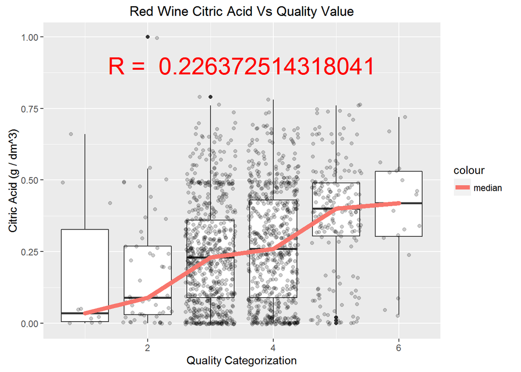

### Description One

The graph above shows the impact of citric acid content on the quality of red wines, with increasing median citric acid content evident with increasing quality value. Displayed above is the Pearson’s R value for citric acid content versus quality value indicating a small positive correlation between citric acid and the quality of red wine.

### Plot Two

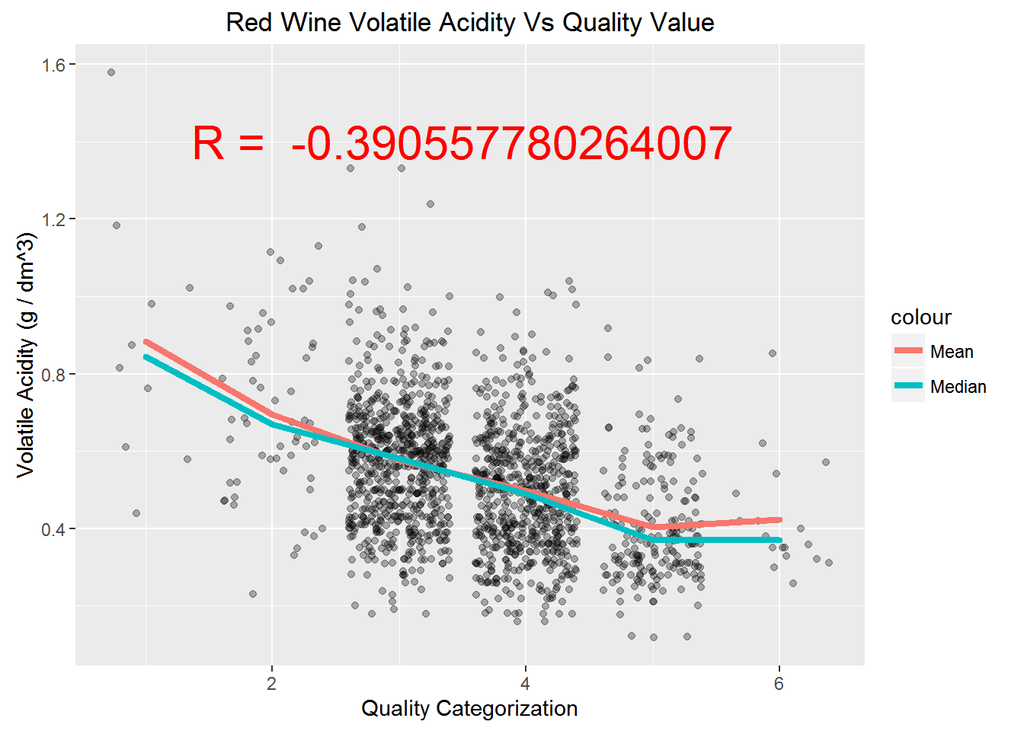

### Plot Three

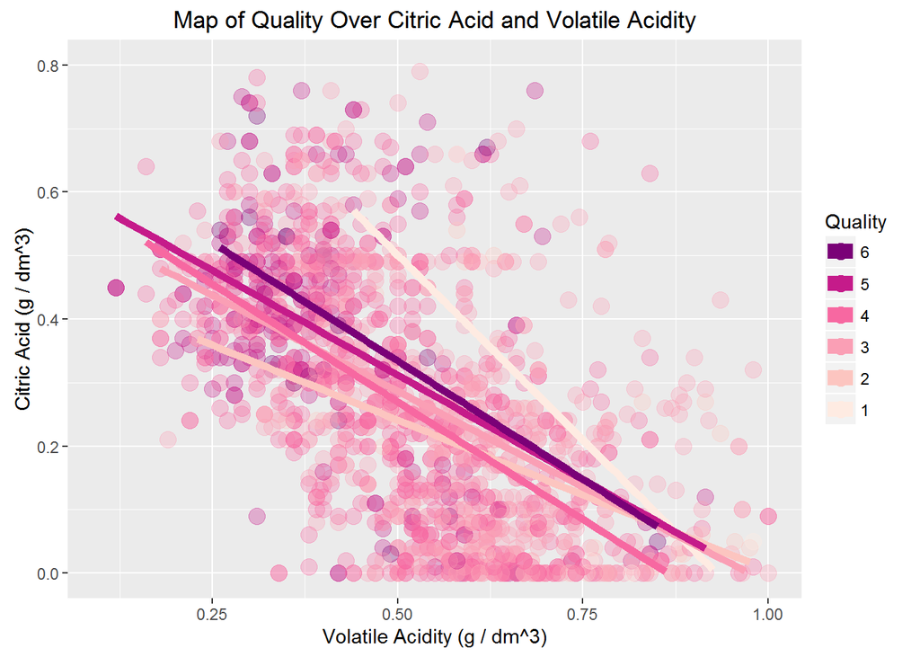

# Reflection

The red wines data set contains a lot of interesting information on red wines and their chemical properties. Though there are multiple interesting relationships between these chemical indicators the most interesting question that could be asked of this data is how these physical attributes play into making a wine of high or low quality. A strong negative relationship between volatile acidity and quality was observed and a linear model based on this and other correlated variables created (though with limited predictive power).

Getting a clear picture of what determines quality in red wines from this data set has proved challenging for several reasons. Firstly the vast majority of the wines fall into the two center-most quality values of 5 and 6. As a result many factors that influence wine quality break down at either end of the scale and making robust models of wine quality are hampered by this tight distribution. An associated issue with this analysis has been the low number of unique values for quality, this limits the granularity of the analysis though treating the quality variable as a factor can be used to complete analysis not possible on more continuous variables. The data-set does not include any measure of wine price, this would greatly increase the number of interesting questions that could be asked. Within each quality grouping there is a high degree of overlap for the values of each of the other associated variables that makes it hard to discern clear patterns of their impact to quality.

For next steps the linear model could be expanded to include other variables of lesser correlation with quality or redesigned completely. A simple but possible more informative way of comparing what a good vs a bad quality wines attributes are may be to bucket wines of quality 2-5 and 6-8 into two groups and compare their summary statistics to find out what makes the high quality group different to the low quality group. There may also be a way to combine multiple chemical properties of the wine into a single variable with greater predictive power on wine quality. Some attempts at this were made above but with no success.